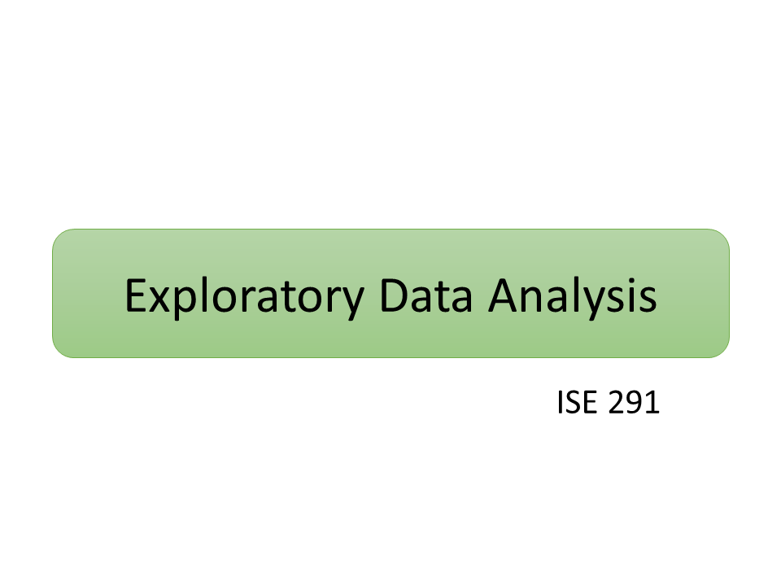

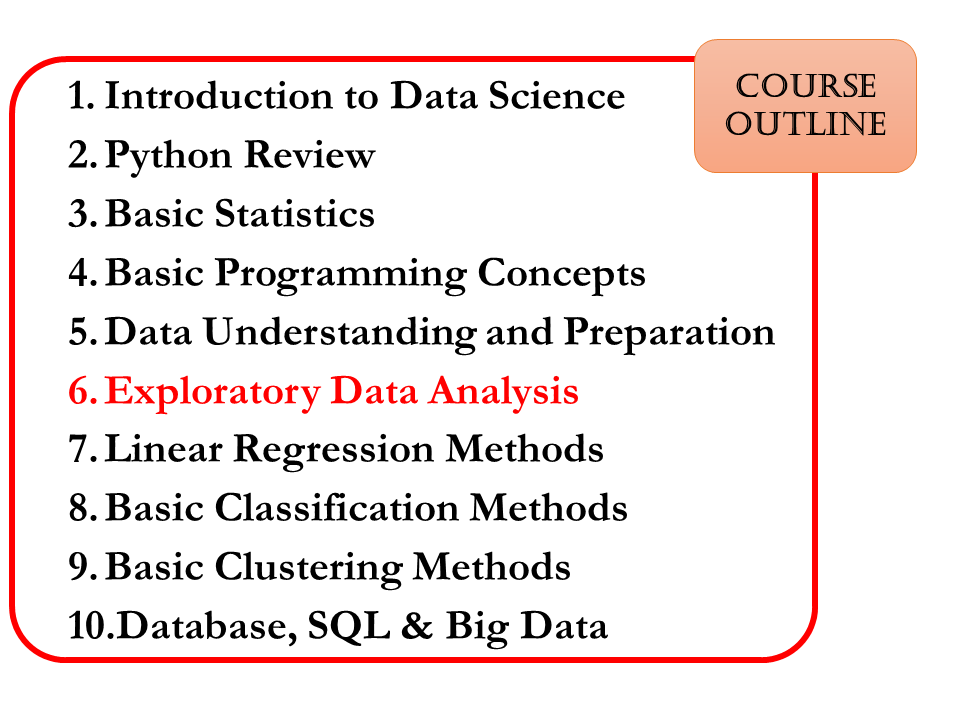

# Exploratory Data Analysis

> 📌 What do we have so far

## Learning Outcomes:

1. Conduct correlation analysis.
2. Explore data using Principal Component Analysis.
3. Conduct data summary analysis.

## Data Analysis and Data Analytics

Data Analysis:

> It is hands-on data exploration and evaluation  
> It looks backwards, providing historical view of what has happened  
> It is not involved in prediction of what will happen

Data Analytics:

> It is a broader term and includes data analysis  
> It is the science behind the analysis  
> It is concerned with the entire methodology

## Categorization of Analysis and Analytics

| Data Analysis | Data Analytics |
| --- | --- |
| Descriptive Analysis | Diagnostic Analytics |
| Exploratory Analysis | Predictive Analytics |
| Mechanistic Analysis | Prescriptive Analytics |

### Descriptive Analysis

> What is happening now (or happened so far).

It typically facilitates in analyzing and summarizing the data. 💡 We have seen descriptive analysis in **Chapter -3**. It typically involves the following:

1. Histogram and Pie-charts to visualize data.
2. Skew and Kurtosis to understand data distribution.
3. Measures of centrality (mean, median, mode)
4. Dispersion of a distribution (range, interquartile range, variance, standard deviation)

### Diagnostic Analytics

> Why something happened?

Sometimes this type of analytics when done hands-on with a small dataset is also known as **causal analysis**

1. It involves at least one cause (usually more than one) and one effect.
2. There are many techniques available in diagnostic analytics.
3. The techniques should be capable of recognizing patterns, detecting anomalies, surfacing ‘unusual’ events
4. **correlation** is one of the most frequently used technique in diagnostic analysis.

### Exploratory Analysis

> Find unknown relationships and patterns.

It typically involves data visualization techniques. The idea is that, plotting the data in different forms could provide us with some clues regarding what we may (or want to) find in data. It consists of range of techniques. The most common goal is looking for patterns in the data.

### Predictive Analytics

> What might happen?

It involves the following steps:

1. Collect data
2. Clean data
3. Identify patterns
4. Make predictions

### Mechanistic Analysis

> How does change in one variable lead to the changes in other variable?

There are many techniques available in Mechanistic analytics, among them **regression** is one of the most frequently used technique.

### Prescriptive Analytics

> What is the best course of action for a given situation?

It involves the following steps:

1. Analyze potential decisions and their interactions
2. Analyze the influences that bear upon these decisions
3. Prescribe an optimal course of action in real time

# Correlation Analysis

> 📌 It describes strength and direction of the relationship between two variables.
1. Strength indicates how closely two variables are related to each other.
2. Direction indicates how one variable would change its value as the value of the other variable changes.

## Pearson's *r* Correlation

The following formula is used for calculating the Pearson's *r* correlation:

$$ r = \frac{N \sum xy-\sum x \sum y}{\sqrt{\left[N\sum x^2-\left(\sum x\right)^2\right]\left[N\sum y^2-\left(\sum y\right)^2\right]}} $$

where  
$r$ = Pearson's *r* correlation coefficient, $-1\leq r \leq 1$  
$N$ = number of values in each dataset/column  
$\sum xy$ = sum of the products of the paired scores/columns  
$\sum x$= sum of x column scores  
$\sum y$= sum of y column scores  
$\sum x^2$= sum of squared x column scores  
$\sum y^2$= sum of squared y column scores

**Directions:** All correlation coefficients between 0 and 1 represent positive correlations, while all coefficients between 0 and -1 are negative correlations. Positive relation means if one increase(decrease), then other will increase(decrease). Negative relation means if one increase(decrease), then other will decrease(increase).

**Strength:** The closer a correlation coefficient is to 1 or to -1, the stronger it is. Following picture [Figure-1] suggests a guideline to interpret the strength.

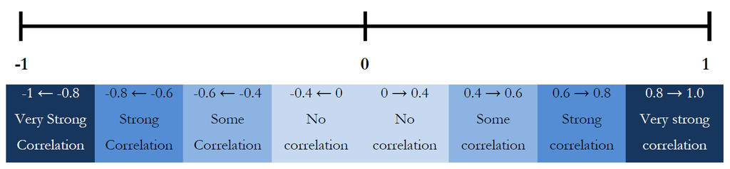

## Example: Correlation Coefficient

**Question A:** A diet company is interested to know if there is a relationship between height and weight of human beings. As a pilot study, they collected the data for ten individuals working in their company. The data given in EDA-1.csv.

1. Use the Pearson's correlation formula to calculate the value of *r* between height and weight.
2. Interpret the strength and direction of their relationship.
3. Use python and verify the above results.

```python
#Read and display data
import pandas as pd
df = pd.read_csv('data/EDA-1.csv', delimiter =',')
display(df)
```

|  | Height | Weight |
| --- | --- | --- |
| 0 | 64.5 | 118 |
| 1 | 73.3 | 143 |
| 2 | 68.8 | 172 |
| 3 | 65.0 | 147 |
| 4 | 69.0 | 146 |
| 5 | 64.5 | 138 |
| 6 | 66.0 | 175 |
| 7 | 66.3 | 134 |
| 8 | 68.8 | 172 |
| 9 | 64.5 | 118 |

1. Use the Pearson's correlation formula to calculate the value of *r* between height and weight.

$N$ = 10  
$\sum xy$ = 98,335.30  
$\sum x$= 670.70  
$\sum y$= 1463  
$\sum x^2$= 45,058.21  
$\sum y^2$= 218,015

which implies $r$ = 0.389

```python
# 3. Use python and verify the above results.
corr = df.corr(method = 'pearson')
display(corr)
```

|  | Height | Weight |
| --- | --- | --- |
| Height | 1.000000 | 0.389583 |
| Weight | 0.389583 | 1.000000 |

# Principal Component Analysis (PCA)

> 📌 Project data into lower dimensions
1. It is a dimensionality reduction technique useful for data visualization and exploration.
2. It is defined as orthogonal projection of the data onto a lower dimensional linear space (principal space) such that the variance of the projected data is maximized.

## 2-dimensional PCA

Consider the following 2d scenario:

[video not shown]

## Intuition behind Principal Component Analysis (PCA)

- The idea is to find directions that capture maximum variations.
- The FIRST principal component, gives us the maximum variation on the principal direction (which is linear combination of original the columns).
- The second principal component, gives us the next maximum variation on another direction (which is perpendicular to the first principal direction). This direction is also a linear combination of original the columns.
- The third principal component, gives us the next maximum variation on another direction (which is perpendicular to the first and second principal direction). This direction is also a linear combination of original the columns.
- Similarly, all the principal components are ranked, based on how much variation they can capture.
- The number of principal component is equal to number of samples (or records) or number of dimensions (or columns) (whichever is smaller)

## Variance Maximization

> Book-2

Let $ \mathbf{x}_{i} $ for $ i=1,\ldots,N $ refers to $ N $ data points in $ m $ dimensions. Let $ \overline{\mathbf{x}} $ be the sample mean vector. Let $ \mathbf{u} $ be the projection vector. The variance of the projected data is given as: $$ Var(\mathbf{u})= \frac{1}{N} \sum_{i=1}^{N} \left(\mathbf{u^Tx_{i}-u^T\overline{\mathbf{x}}}\right)^2$$

which is simplified as: $Var(\mathbf{u})= \mathbf{u^{T}Su} $

where $ \mathbf{S} $ is data covariance matrix, defined as:

$$ \mathbf{S}=\frac{1}{N} \sum_{i=1}^{N} (\mathbf{x_{i}-\overline{\mathbf{x}} })(\mathbf{x_{i}-\overline{\mathbf{x}} })^{T} $$

### Obtaining Principal Components (PC)

Following steps can be used for obtaining PCs.

1. Find a unit vector that maximizes $Var(\mathbf{u})$. This is the first PC.
2. Find next PC, *unit vector orthogonal to previously found PCs*, which maximizes $Var(\mathbf{u})$.
3. Repeat Step-2 until all *or required* PC are obtained.

Note: there are many efficient algorithms in the literature that obtains PCs. We will use sci-kit learn's **sklearn.decomposition** library to obtain PCs.

## Case Study-1: PCA

A car manufacturing company is planning to identify the relationship between various factors and the *economy* (fuel efficiency) of the vehicle. All the input variables and the *economy* information is stored in EDA-2.csv data.

1. Read and display the data & data info.
2. Add the first two principal components to the database and name the column names as *pca1* & *pca2*.
3. How much variation is captured by each of the principal components.
4. For the first principal component:  
   i. What are the coefficients of the linear combination of the columns.  
   ii. Which column has highest coefficient.
5. Construct a scatter plot using the first two principal components of the data. Differentiate the point using *economy*. In a separate plot, differentiate them using *origin*. In a separate plot, differentiate them using *cylinders*.
6. Construct a scatter plot using the first two principal components of the data. Differentiate the point using *economy* and *origin*.
7. Construct a scatter plot using the first two principal components of the data. Differentiate the point using *economy*, *origin* and *cylinders*.
8. Can the first two principal components separate *economy* information (conclude from part(5)).
9. From part(5), it looks like PCA can separate *cylinders* information. Is it valid conclusion.
10. The principal components correspond to any of the existing variables?

```python
#1. Read and display the data & data info.
import numpy as np
import pandas as pd
df = pd.read_csv('data/EDA-2.csv', delimiter = ',')
display(df.head(5))
display(df.info())
```

|  | origin | car_name | model_year | cylinders | displacement | horsepower | weight | acceleration | mpg | economy |
| --- | --- | --- | --- | --- | --- | --- | --- | --- | --- | --- |
| 0 | american | chevrolet | 70 | 8 | 307.0 | 130 | 3504 | 12.0 | 18.0 | 1 |
| 1 | american | buick | 70 | 8 | 350.0 | 165 | 3693 | 11.5 | 15.0 | 0 |
| 2 | american | plymouth | 70 | 8 | 318.0 | 150 | 3436 | 11.0 | 18.0 | 1 |
| 3 | american | amc | 70 | 8 | 304.0 | 150 | 3433 | 12.0 | 16.0 | 1 |
| 4 | american | ford | 70 | 8 | 302.0 | 140 | 3449 | 10.5 | 17.0 | 1 |

```
<class 'pandas.core.frame.DataFrame'>
RangeIndex: 392 entries, 0 to 391
Data columns (total 10 columns):
 #   Column        Non-Null Count  Dtype
---  ------        --------------  -----
 0   origin        392 non-null    object
 1   car_name      392 non-null    object
 2   model_year    392 non-null    int64
 3   cylinders     392 non-null    int64
 4   displacement  392 non-null    float64
 5   horsepower    392 non-null    int64
 6   weight        392 non-null    int64
 7   acceleration  392 non-null    float64
 8   mpg           392 non-null    float64
 9   economy       392 non-null    int64
dtypes: float64(3), int64(5), object(2)
memory usage: 30.8+ KB
```

```
None
```

```python
# 2. Add the first two principal components to the database
# and name the column names as *pca1* & *pca2*.

## Only numerical columns can be used to get principal components.
# You can ENCODE all the non-numerical columns to numerical, if needed.
# Here we use the existing numerical columns as INPUT columns for obtaining principal components.
## NOTE: if you have an OUTPUT columns (given in the scenario, then do not use them as input columns)
# For example: here we assume column economy is an OUTPUT column

num_columns = df.select_dtypes(exclude='object').columns
pca_input_columns=num_columns.drop(['economy'])

from sklearn.decomposition import PCA
pca = PCA(n_components=2) # get pca model

principalComponents = pca.fit_transform(df[pca_input_columns]) # get two components

## # Same as above in two steps
# pca.fit(df[pca_input_columns])
# principalComponents = pca.transform(df[pca_input_columns])

df['pca1'] = principalComponents[:,0]
df['pca2'] = principalComponents[:,1]


display(df)

### another approach to add new columns to an existing dataframe!
# df=pd.concat([df, pd.DataFrame(principalComponents)], axis=1) # add the two components
# df.rename(columns = {0:'pca1',1:'pca2'}, inplace = True)

## See more about the .concat() method
# # help(pd.concat)
```

|  | origin | car_name | model_year | cylinders | displacement | horsepower | weight | acceleration | mpg | economy | pca1 | pca2 |
| --- | --- | --- | --- | --- | --- | --- | --- | --- | --- | --- | --- | --- |
| 0 | american | chevrolet | 70 | 8 | 307.0 | 130 | 3504 | 12.0 | 18.0 | 1 | 536.470596 | 50.847393 |
| 1 | american | buick | 70 | 8 | 350.0 | 165 | 3693 | 11.5 | 15.0 | 0 | 730.384302 | 79.175442 |
| 2 | american | plymouth | 70 | 8 | 318.0 | 150 | 3436 | 11.0 | 18.0 | 1 | 471.009139 | 75.469201 |
| 3 | american | amc | 70 | 8 | 304.0 | 150 | 3433 | 12.0 | 16.0 | 1 | 466.444308 | 62.594070 |
| 4 | american | ford | 70 | 8 | 302.0 | 140 | 3449 | 10.5 | 17.0 | 1 | 481.702722 | 55.820351 |
| ... | ... | ... | ... | ... | ... | ... | ... | ... | ... | ... | ... | ... |
| 387 | american | ford | 82 | 4 | 140.0 | 86 | 2790 | 15.6 | 27.0 | 1 | -193.183295 | -34.516523 |
| 388 | european | volkswagen | 82 | 4 | 97.0 | 52 | 2130 | 24.6 | 44.0 | 2 | -854.711622 | -6.160509 |
| 389 | american | dodge | 82 | 4 | 135.0 | 84 | 2295 | 11.6 | 32.0 | 2 | -685.224710 | 20.039018 |
| 390 | american | ford | 82 | 4 | 120.0 | 79 | 2625 | 18.6 | 28.0 | 1 | -359.540884 | -35.695578 |
| 391 | american | chevy | 82 | 4 | 119.0 | 82 | 2720 | 19.4 | 31.0 | 2 | -265.260929 | -47.309005 |

392 rows × 12 columns

```python
# 3. How much variation is captured by each of the principal components.

# the variance captured by each principal component is available in .explained_variance_ratio_ attribute
# see what is inside the attribute by print(pca.explained_variance_ratio_)
# we can print the above attributes information as follows:

for ind,var in enumerate(pca.explained_variance_ratio_):
    print(f'The variance captured by pca {ind+1} is: {var*100: 0.2f}%')
```

```
The variance captured by pca 1 is:  99.75%
The variance captured by pca 2 is:  0.21%
```

```python
# 4. For the first principal component:
#    i. What are the coefficients of the linear combination of the columns.
#   ii. Which column has highest coefficient.

# The coefficients for each principal component is given in attribute .components_
# see what is inside the attribute by print(pca.components_)
# we can print the above attributes information as follows:

pca_1_coefficients=np.round(pca.components_[0],4)

zipList=list(zip(pca_input_columns,pca_1_coefficients))
ndf=pd.DataFrame.from_records(zipList,columns=['field','coeff'])

display(ndf.sort_values(by=['coeff'], ascending=False))  # remember to consider abs() for negative values...
```

|  | field | coeff |
| --- | --- | --- |
| 4 | weight | 0.9926 |
| 2 | displacement | 0.1143 |
| 3 | horsepower | 0.0390 |
| 1 | cylinders | 0.0018 |
| 0 | model_year | -0.0013 |
| 5 | acceleration | -0.0014 |
| 6 | mpg | -0.0076 |

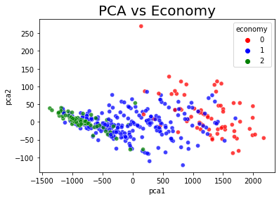

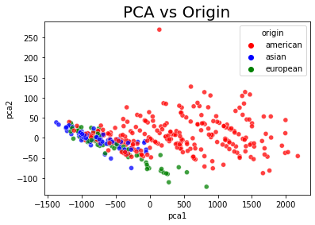

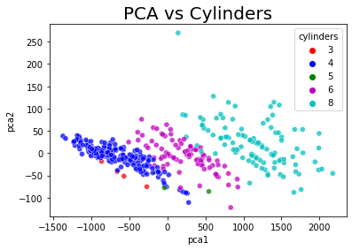

```python
# 5. Construct a scatter plot using the first two principal components of the data.
#Differentiate the points using *economy*. In a separate plot, differentiate them using *origin*.
#In a separate plot, differentiate them using *cylinders*.

import matplotlib.pyplot as plt
import seaborn as sns
# plt.figure()
# sns.scatterplot(x='pca1',y='pca2',
#             alpha=0.75,
#             data=df)
# plt.title('PCA vs Economy', fontsize = 20)
# plt.show()



plt.figure()
sns.scatterplot(x='pca1',y='pca2',
            hue='economy', palette=['r','b','g'],
            alpha=0.75,
            data=df)
plt.title('PCA vs Economy', fontsize = 20)
plt.show()


plt.figure()
sns.scatterplot(x='pca1',y='pca2',
            hue='origin', palette=['r','b','g'],
            alpha=0.75,
            data=df)
plt.title('PCA vs Origin', fontsize = 20)
plt.show()


plt.figure()
sns.scatterplot(x='pca1',y='pca2',
            hue='cylinders', palette=['r','b','g','m','c'],
            alpha=0.75,
            data=df)
plt.title('PCA vs Cylinders', fontsize = 20)
plt.show()
```

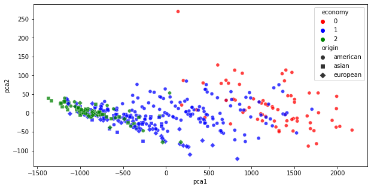

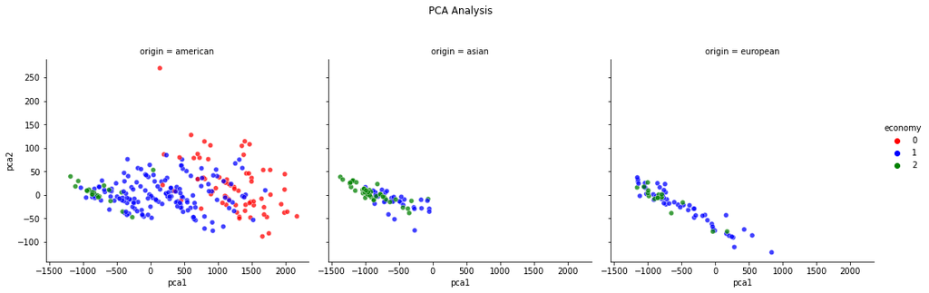

```python
# 6. Construct a scatter plot using the first two principal components of the data.
#Differentiate the point using *economy* and *origin*.

import matplotlib.pyplot as plt
import seaborn as sns
plt.figure(figsize=(10,5))
sns.scatterplot(x='pca1',y='pca2',
            hue='economy', palette=['r','b','g'],
            style='origin',markers=['o','s','D'],
            alpha=0.75,
            data=df)
plt.show()

# or following plot can be used
plt.figure()
h=sns.relplot(x='pca1',y='pca2',
            hue='economy', palette=['r','b','g'],
            col='origin',
            kind='scatter',alpha=0.75,
            height=5, aspect=1,
            data=df)
h.fig.suptitle('PCA Analysis') # Title for the complete figure
h.fig.subplots_adjust( top = 0.8 ) # Adjust subplots so that titles don't overlap with main title
plt.show()
```

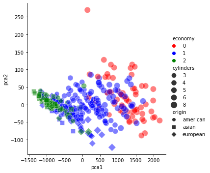

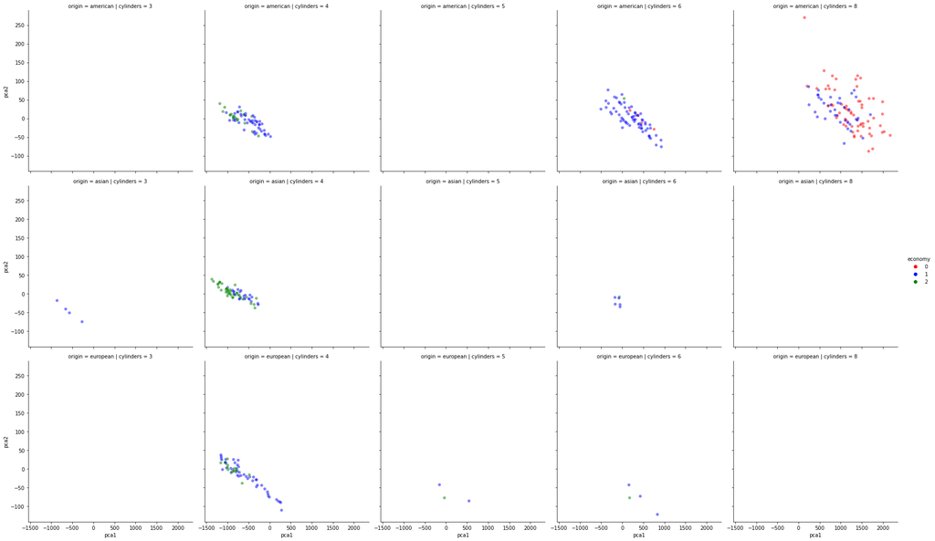

```python
# 7. Construct a scatter plot using the first two principal components of the data.
#Differentiate the point using *economy*, *origin* and *cylinders*.

import matplotlib.pyplot as plt
import seaborn as sns
plt.figure()
sns.relplot(x='pca1',y='pca2',
            hue='economy', palette=['r','b','g'],
            size='cylinders', sizes=(75, 150),
            style='origin',markers=['o','s','D'],
            kind='scatter',alpha=0.5,
            height=5, aspect=1,
            data=df)
plt.show()


import matplotlib.pyplot as plt
import seaborn as sns
plt.figure()
sns.relplot(x='pca1',y='pca2',
            hue='economy', palette=['r','b','g'],
            col='cylinders',
            row='origin',
            kind='scatter',alpha=0.5,
            height=5, aspect=1,
            data=df)
plt.show()
```

1. Can the first two principal components separate *economy* information (conclude from part(5)).  
   The PCAs show good separation, with some overlap.
2. From part(5), it looks like PCA can separate *cylinders* information. Is it valid conclusion.  
   It is not a valid conclusion, since the information of *cylinders* was considered during the construction of PCAs.
3. The principal components correspond to any of the existing variables?  
   No, they principal components do not correspond to any of the existing variables. They are linear combination of (some) existing variables.

# Data Summary Analysis

> 📌 Here we explore the data using descriptive and exploratory data analysis techniques.

## Case Study-2: Summary Analysis

A bank is interested in identifying potential customers for their new term deposit policy. They plan to call the customers and invite them to join the policy. However, calling all the customers will cost time and money. Thus, they decided to see from the past data if they can identify a pattern that will help to identify traits of the possible customers. The collected data is given in EDA-3.csv. Conduct the following on the data:

1. Read and display the data, data info, and summary statistics. Is there any inconsistency?
2. Identify the numeric and non-numeric data columns.
3. Descriptive plots (histograms) for the non-numeric data columns using the following strategies:
   - i. Histograms for each column
   - ii. Histograms for each column differentiated with *subscribed* column.
   - iii. Histograms depicting *job*, and differentiated with *subscribed* & *education* columns.
   - iv. Histograms depicting *job*, and differentiated with *subscribed, education & marital* columns.
4. Descriptive plots (histograms) for the numeric data columns using the following strategies:
   - i. Histograms for each column with kernel density.
   - ii. Histograms for each column differentiated by *subscribed* column.
   - iii. Draw a bivariate histogram for *age* and *balance* columns.
   - iv. Pair plots for every pair of columns differentiated with *subscribed* column.
5. For both (numerical and categorical) columns, do the following:
   - i. Crosstable showing the total number of customers for *education & job* columns.
   - ii. Pivot table displaying total subscribers for *marital, job & education* columns.
   - iii. Box-Plots for each numerical and categorical column (skip *subscribed* column), and differentiate using *subscribed* column.
6. Which age group subscribed the most.
7. Which combination of *job* & *education* has the most customers.
8. Which combination of *marital*, *job* & *education* subscribed the most.
9. The bank is planning to have a new scheme for students. Which age group students should they consider mostly?

```python
# 1. Read and display the data, data info, and summary statistics.

import pandas as pd
# import numpy as np
df = pd.read_csv('data/EDA-3.csv', delimiter = ',')

display(df.sample(5))
display(df.info())

# display(df.describe(include='all'))
display(df.describe(include='number'))
display(df.describe(include='object'))

print("No inconsistency")
```

|  | age | job | marital | education | default | balance | housing | loan | subscribed |
| --- | --- | --- | --- | --- | --- | --- | --- | --- | --- |
| 2113 | 31 | admin. | married | secondary | no | 2304 | yes | no | no |
| 1321 | 40 | services | married | secondary | no | 17 | no | no | no |
| 2221 | 34 | management | married | tertiary | no | 573 | no | no | no |
| 2971 | 37 | blue-collar | married | secondary | no | 346 | yes | no | no |
| 1742 | 55 | retired | married | primary | no | 150 | no | no | no |

```
<class 'pandas.core.frame.DataFrame'>
RangeIndex: 4521 entries, 0 to 4520
Data columns (total 9 columns):
 #   Column      Non-Null Count  Dtype
---  ------      --------------  -----
 0   age         4521 non-null   int64
 1   job         4521 non-null   object
 2   marital     4521 non-null   object
 3   education   4521 non-null   object
 4   default     4521 non-null   object
 5   balance     4521 non-null   int64
 6   housing     4521 non-null   object
 7   loan        4521 non-null   object
 8   subscribed  4521 non-null   object
dtypes: int64(2), object(7)
memory usage: 318.0+ KB
```

```
None
```

|  | age | balance |
| --- | --- | --- |
| count | 4521.000000 | 4521.000000 |
| mean | 41.170095 | 1422.657819 |
| std | 10.576211 | 3009.638142 |
| min | 19.000000 | -3313.000000 |
| 25% | 33.000000 | 69.000000 |
| 50% | 39.000000 | 444.000000 |
| 75% | 49.000000 | 1480.000000 |
| max | 87.000000 | 71188.000000 |

|  | job | marital | education | default | housing | loan | subscribed |
| --- | --- | --- | --- | --- | --- | --- | --- |
| count | 4521 | 4521 | 4521 | 4521 | 4521 | 4521 | 4521 |
| unique | 12 | 3 | 4 | 2 | 2 | 2 | 2 |
| top | management | married | secondary | no | yes | no | no |
| freq | 969 | 2797 | 2306 | 4445 | 2559 | 3830 | 4000 |

```
No inconsistency
```

```python
# 2. Identify the numeric and non-numeric data columns.

num_columns = df.select_dtypes(exclude='object').columns
cat_columns = df.select_dtypes(include='object').columns

print(f'Numerical columns are: {num_columns.tolist()}')
print(f'Non-numerical columns are: {cat_columns.tolist()}')
```

```
Numerical columns are: ['age', 'balance']
Non-numerical columns are: ['job', 'marital', 'education', 'default', 'housing', 'loan', 'subscribed']
```

```python
# 3. Descriptive plots (histograms) for the non-numeric data columns using the following strategies:
#     - i. Histograms for each column
#    - ii. Histograms for each column differentiated with *subscribed* column.
#    - iii. Histograms depicting *job*, and differentiated with *subscribed* & *education* columns.
#    - iv. Histograms depicting *job*, and differentiated with *subscribed, education & marital* columns.
```

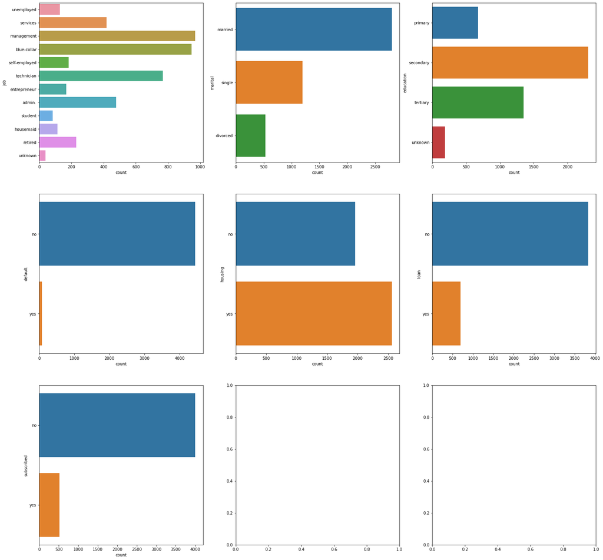

```python
# 3.i. Histograms for each column
%matplotlib inline
from matplotlib import pyplot as plt
import seaborn as sns

nCols=3   # The number of columns that you want
nRows=len(cat_columns)//nCols+1   # The number of correspomding rows

## to avoid rotating labels:
fig,axes = plt.subplots(nRows, nCols, figsize=(25,25))
for ind,col in enumerate(cat_columns):
    sns.countplot(y=col,data=df,ax=axes.flatten()[ind])
plt.show()

# ## to have it on x axis:
# fig,axes = plt.subplots(nRows, nCols, figsize=(25,25))
# for ind,col in enumerate(cat_columns):
#     axis=axes.flatten()[ind]
#     sns.countplot(x=col,data=df,ax=axis)
#     axis.set_xticklabels(axis.get_xticklabels(), rotation=80)
# plt.show()

# ## or you can draw one by one figures (like in the previous chapters)
# for col in cat_columns:
#     plt.figure(figsize=(5,5))
#     sns.countplot(y=col,hue='subscribed',data=df)
#     plt.show()
```

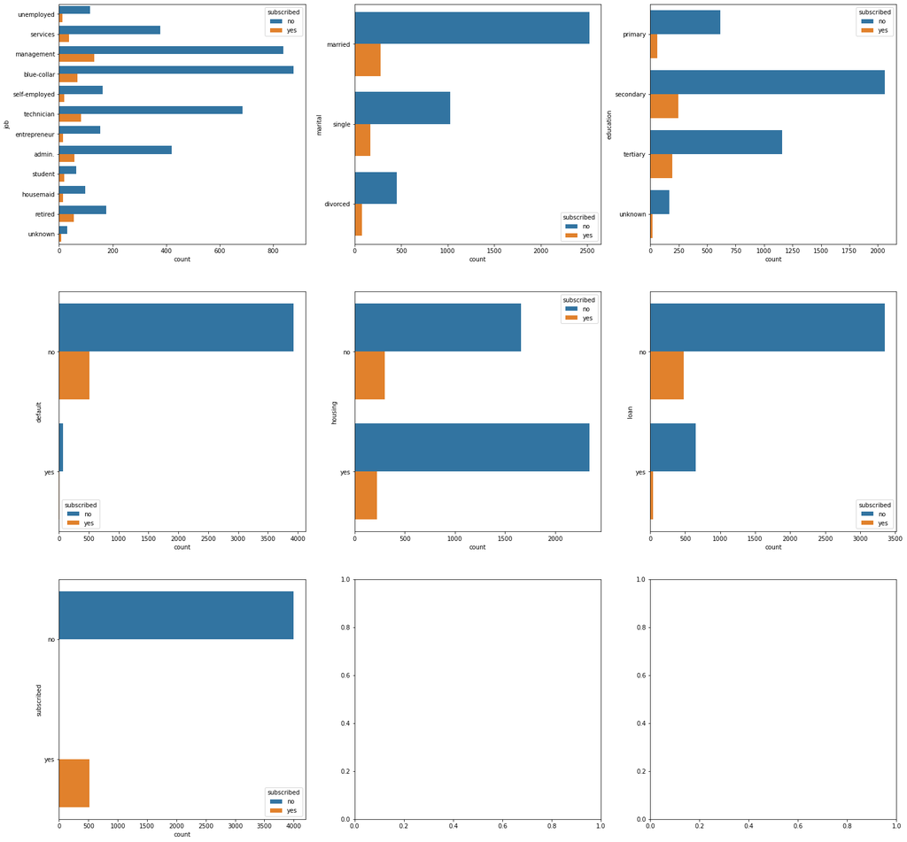

```python
#   3.ii. Histograms for each column differentiated with *subscribed* column.

nCols=3   # The number of columns that you want
nRows=len(cat_columns)//nCols+1   # The number of correspomding rows

fig,axes = plt.subplots(nRows, nCols, figsize=(25,25))
for ind,col in enumerate(cat_columns):
    sns.countplot(y=col,hue='subscribed',data=df,ax=axes.flatten()[ind])
plt.show()

## or you can draw one by one figures (like in the previous chapters)
# for col in cat_columns:
#     plt.figure(figsize=(5,5))
#     sns.countplot(y=col,hue='subscribed',data=df)
#     plt.show()
```

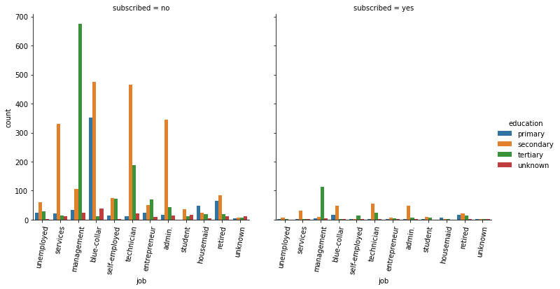

```python
#   3.iii. Histograms depicting *job*, and differentiated with *subscribed* & *education* columns.

plt.figure()
g=sns.catplot(x="job", col="subscribed", hue="education", data=df, kind="count")
g.set_xticklabels(rotation=80)
plt.show()

# ## to avoid rotating labels
# plt.figure()
# sns.catplot(y="job", col="subscribed", hue="education", data=df, kind="count")
# plt.show()
```

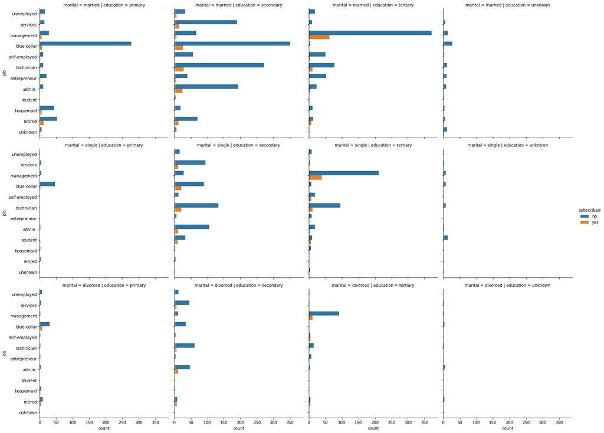

```python
#    3.iv. Histograms depicting *job*, and differentiated with *subscribed, education & marital* columns.
plt.figure()
sns.catplot(kind="count",y="job", hue="subscribed", row='marital', col="education", data=df)
plt.show()
```

```python
# 4. Descriptive plots (histograms) for the numeric data columns using the following strategies:
#     - i. Histograms for each column with kernel density.
#     - ii. Histograms for each column differentiated by *subscribed* column.
#     - iii. Draw a bivatiate histogram for *age* and *balance* columns.
#     - iv. Pair plots for every pair of columns differentiated with *subscribed* column.
```

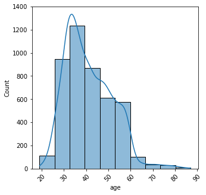

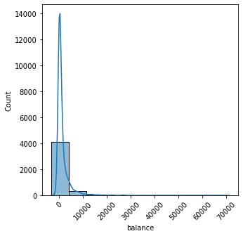

```python
#     4.i. Histograms for each column with kernel density
for col in num_columns:
    plt.figure(figsize=(5,5))
    sns.histplot(x=col,bins=10,kde=True,data=df)
    plt.xticks(rotation=45)
    plt.show()
```

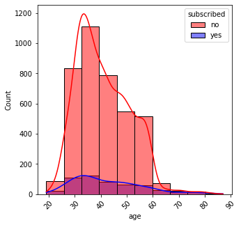

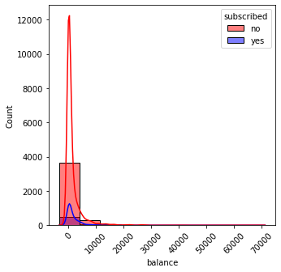

```python
#     4.ii. Histograms for each column differentiated by *subscribed* column.
for col in num_columns:
    plt.figure(figsize=(5,5))
    sns.histplot(x=col,bins=10,hue='subscribed',kde=True,data=df,palette=['r','b'])
    plt.xticks(rotation=45)
    plt.show()
```

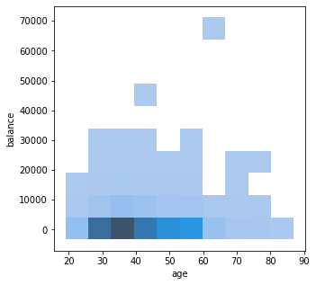

```python
#     4.iii. Draw a bivariate histogram for *age* and *balance* columns.
plt.figure(figsize=(5,5))
sns.histplot(x='age', y='balance', bins=10, data=df)
plt.show()
```

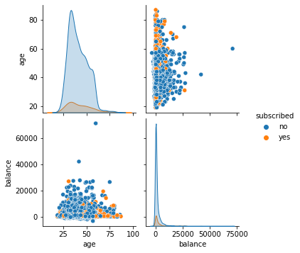

```python
#     4.iv. Pair plots for every pair of numerical columns differentiated with *subscribed* column.
plt.figure()
sns.pairplot(vars=num_columns,hue ='subscribed',data=df)   # look for {x, y}_vars kwargs
plt.show()

# # following code can be used too
# plt.figure()
# sns.pairplot(hue ='subscribed',data=df[num_columns].join(df['subscribed']))
# plt.show()

# xCols, yCols = np.split(num_columns,2)
# plt.figure()
# sns.pairplot(x_vars=xCols,y_vars=yCols,hue ='subscribed',data=df)   # {x, y}_vars kwargs can be used to draw specific plots
# plt.show()

# sns.pairplot(hue ='subscribed',data=df[num_columns])  ## Note: this will not work
```

```python
# 5. For both (numerical and categorical) columns, do the following:
#     - i. Crosstable showing the total number of subscribers for *education & job* columns.
#     - ii. Pivot table displaying total *balance* for *marital, job & education* columns.
#     - iii. Box-Plots for each numerical and categorical column (skip *subscribed* column), and differentiate using *subscribed* column.
```

```python
#     5.i. Crosstable showing the total number of customers for *education & job* columns.
ctab = pd.crosstab(df['job'],df['education'])
display(ctab)

# help(pd.crosstab)
```

| education job | primary | secondary | tertiary | unknown |
| --- | --- | --- | --- | --- |
| admin. | 17 | 393 | 51 | 17 |
| blue-collar | 369 | 524 | 12 | 41 |
| entrepreneur | 26 | 58 | 73 | 11 |
| housemaid | 57 | 28 | 22 | 5 |
| management | 39 | 116 | 787 | 27 |
| retired | 80 | 105 | 31 | 14 |
| self-employed | 15 | 76 | 88 | 4 |
| services | 25 | 363 | 16 | 13 |
| student | 2 | 47 | 19 | 16 |
| technician | 15 | 520 | 211 | 22 |
| unemployed | 26 | 68 | 32 | 2 |
| unknown | 7 | 8 | 8 | 15 |

```python
#     5.ii. Pivot table displaying total *subscribers* for *marital, job & education* columns.

df['subscribed_num'] = df['subscribed'].apply(lambda x: 1 if x == 'yes' else 0)
pTable=df.pivot_table(values=['subscribed_num'],
                       index=['marital', 'job'],
                       columns=['education'],
                       aggfunc=sum)  # the default aggFunc will be mean

display(pTable)
df.drop(['subscribed_num'], axis=1, inplace=True)  # the column was created just for the pivot table
```

| marital | education job | subscribed_num primary | subscribed_num secondary | subscribed_num tertiary | subscribed_num unknown |
| --- | --- | --- | --- | --- | --- |
| divorced | admin. | 0.0 | 11.0 | 0.0 | 0.0 |
|  | blue-collar | 7.0 | 2.0 | NaN | 1.0 |
|  | entrepreneur | 0.0 | 1.0 | 1.0 | 1.0 |
|  | housemaid | 2.0 | 2.0 | 0.0 | NaN |
|  | management | 0.0 | 0.0 | 11.0 | 1.0 |
|  | retired | 4.0 | 8.0 | 4.0 | 0.0 |
|  | self-employed | 0.0 | 0.0 | 5.0 | NaN |
|  | services | 1.0 | 7.0 | 0.0 | 0.0 |
|  | technician | 0.0 | 6.0 | 2.0 | 0.0 |
|  | unemployed | 0.0 | 0.0 | 0.0 | NaN |
|  | unknown | NaN | NaN | 0.0 | NaN |
| married | admin. | 1.0 | 25.0 | 4.0 | 1.0 |
|  | blue-collar | 7.0 | 26.0 | 0.0 | 2.0 |
|  | entrepreneur | 2.0 | 5.0 | 2.0 | 0.0 |
|  | housemaid | 5.0 | 1.0 | 1.0 | 0.0 |
|  | management | 5.0 | 6.0 | 63.0 | 3.0 |
|  | retired | 12.0 | 13.0 | 8.0 | 3.0 |
|  | self-employed | 2.0 | 2.0 | 3.0 | 1.0 |
|  | services | 1.0 | 14.0 | 1.0 | 0.0 |
|  | student | NaN | 0.0 | 1.0 | 0.0 |
|  | technician | 2.0 | 28.0 | 11.0 | 1.0 |
|  | unemployed | 2.0 | 6.0 | 1.0 | 0.0 |
|  | unknown | 2.0 | 1.0 | 0.0 | 3.0 |
| single | admin. | 0.0 | 12.0 | 3.0 | 1.0 |
|  | blue-collar | 2.0 | 21.0 | 1.0 | 0.0 |
|  | entrepreneur | 1.0 | 1.0 | 1.0 | NaN |
|  | housemaid | 1.0 | 0.0 | 2.0 | 0.0 |
|  | management | 0.0 | 3.0 | 39.0 | 0.0 |
|  | retired | 0.0 | 1.0 | 1.0 | 0.0 |
|  | self-employed | 0.0 | 0.0 | 7.0 | 0.0 |
|  | services | 1.0 | 11.0 | 1.0 | 1.0 |
|  | student | 2.0 | 10.0 | 6.0 | 0.0 |
|  | technician | 1.0 | 21.0 | 11.0 | 0.0 |
|  | unemployed | 1.0 | 1.0 | 2.0 | 0.0 |
|  | unknown | NaN | 0.0 | 1.0 | 0.0 |

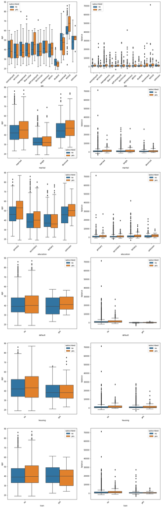

```python
#     5.iii. Box-Plots for each numerical and categorical column (skip *subscribed* column),
# and differentiate using *subscribed* column.


cat_columns = df.select_dtypes('object').columns.drop('subscribed')
num_columns = df.select_dtypes(exclude='object').columns


fig,axes = plt.subplots(len(cat_columns), len(num_columns), figsize=(15,50))
for c,nCol in enumerate(num_columns):
    for r,cCol in enumerate(cat_columns):
        axis=axes[r][c]
        sns.boxplot(x=cCol,y=nCol,hue='subscribed',data=df, ax=axis)
        axis.set_xticklabels(axis.get_xticklabels(), rotation=45)
plt.show()
```

1. Which age group subscribed the most.  
   Age group between 30 to 40 *(from 4.ii)*.

```python
# 7. Which combination of *job* & *education* has the most customers.

display(pd.concat([ctab.idxmax(), ctab.max()], axis=1))

print("Management job with tertiary education  (from 5.i). ")
```

| education | 0 | 1 |
| --- | --- | --- |
| primary | blue-collar | 369 |
| secondary | blue-collar | 524 |
| tertiary | management | 787 |
| unknown | blue-collar | 41 |

```
Management job with tertiary education  (from 5.i).
```

```python
# 8. Which combination of *marital*, *job* & *education* subscribed the most.

display(pd.concat([pTable.idxmax(), pTable.max()], axis=1))

print("Management job with tertiary education who are married (from 5.ii). ")
```

|  | education | 0 | 1 |
| --- | --- | --- | --- |
| subscribed_num | primary | (married, retired) | 12.0 |
|  | secondary | (married, technician) | 28.0 |
|  | tertiary | (married, management) | 63.0 |
|  | unknown | (married, management) | 3.0 |

```
Management job with tertiary education who are married (from 5.ii).
```

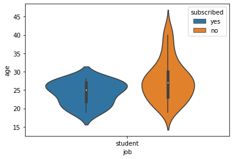

```
The should consider mostly students between ages 22.0 and 27.0, maybe focusing towards the higher side 27.0.
```

```python
# 9. The bank is planning to have a new scheme for students. Which age group students should they consider mostly?
selected_rows = df['job']=='student'
plt.figure()
sns.violinplot(y="age",x="job",hue="subscribed",data=df.loc[selected_rows,:])
plt.show()


selected_rows = (df['job']=='student') & (df['subscribed']=='yes')
Q1,Q3=df.loc[selected_rows,'age'].describe().loc[['25%','75%']]
print(f"The should consider mostly students between ages {Q1} and {Q3}, maybe focusing towards the higher side {Q3}.")
```

# References

## Theory:

1. Chirag Shah, "A Hands-On Introduction to Data Science," Cambridge University Press, 2020, **Chapter 3, skip 3.8.1**. 📕
2. Bishop, Christopher M., "Pattern recognition and machine learning," Springer, 2006, **Section 12.1.1**. 📕

## Data Sets:

1. EDA-1: Chirag Shah, "A Hands-On Introduction to Data Science," Cambridge University Press, 2020, OA 9.6.
2. EDA-2: *Modified* Auto MPG Data, UCI Machine Learning Repository [http://archive.ics.uci.edu/ml]. Irvine, CA: University of California, School of Information and Computer Science. Published in: Quinlan,R. (1993). Combining Instance-Based and Model-Based Learning. In Proceedings on the Tenth International Conference of Machine Learning, 236-243, University of Massachusetts, Amherst. Morgan Kaufmann.
3. EDA-3: *Modified* Bank Marketing Data, UCI Machine Learning Repository [http://archive.ics.uci.edu/ml]. Irvine, CA: University of California, School of Information and Computer Science. Published in: S. Moro, P. Cortez and P. Rita. A Data-Driven Approach to Predict the Success of Bank Telemarketing. Decision Support Systems, Elsevier, 62:22-31, June 2014

## Others:

1. Correlation: https://pandas.pydata.org/pandas-docs/stable/reference/api/pandas.DataFrame.corr.html 📃
2. PCA: https://scikit-learn.org/stable/modules/generated/sklearn.decomposition.PCA.html 📃
3. Seaborn Relplot: https://seaborn.pydata.org/generated/seaborn.relplot.html 📃
4. Axes: https://matplotlib.org/3.3.3/api/axes_api.html 📃
5. Seaborn Histplot: https://seaborn.pydata.org/generated/seaborn.histplot.html 📃
6. Cross table: https://pandas.pydata.org/pandas-docs/stable/reference/api/pandas.crosstab.html 📃
7. Pivot table: https://pandas.pydata.org/pandas-docs/stable/reference/api/pandas.pivot_table.html 📃

## Images:

1. Figure-1: Matthew North, "Data Mining for the Masses". 📕